# Unit 10 Lab Report

Christopher Byrd

2024-11-28

### Section 1: Hypothesis

The goal of this research paper is to determine if age of those who pray regularly has a statistically significant effect on income. The following are the hypothesizes examined:

> Null: There is no significant correlation between age of those who pray regularly and their income.  
> Research<sub>1</sub>: There is a significant correlation between age of those who pray regularly and their income.

> H<sub>0</sub>: ρ<sub>xy</sub> = 0  
> H<sub>1</sub>: r<sub>xy</sub> ≠ 0

### Section 2: Data

The data being utilized is from the Baylor Survey of Religious Life. Participants who prayed at least once or more a day were asked to respond with their age and the bracket in which their income falls within. The following code book was used:

| Question or Description | Possible Answers |
| --- | --- |
| Age range of people who | Range: 17-95 |
| pray once or several times |  |
| a day as reported in 2017. |  |
| ————————— | ———————————– |
| By your best estimate, | 1) $10,000 or less |
| what was your total | 2) $10,001 to $20,000 |
| household income last year, | 3) $20,001 to $35,000 |
| before taxes? | 4) $35,001 to $50,000 |
|  | 5) $50,001 to $100,000 |
|  | 6) $100,001 to $150,000 |
|  | 7) $150,001 or more |

### Section 3: Method

To evaluate the data, Pearson’s r was calculated using `rcorr`, a function which evaluates Pearson’s r and the associated P-value. The data needed to be coerced into a matrix to allow calculation of each variable. The other option that exists is to create two separate data frames for each variable.

```r
rcorr(as.matrix(Module_10_Lab_Data), type = "pearson")
```

To determine $R^2$, I took a function off the internet to create a function for evaluating $R^2$. The original function required you to coerce the variables to be matrices, so I put it in the function to avoid this.

```r
rsq <- function (x, y) cor(as.matrix(x), as.matrix(y)) ^ 2

rsq(Module_10_Lab_Data, Module_10_Lab_Data)
```

Lastly, ggplot2 was used to produce a scatter plot. This was achieved through the geom `geom_point()`, while `geom_smooth()` was used to create the trend line.

```r
graphdata <- as.data.frame(Module_10_Lab_Data)

ggplot(data = graphdata, aes(x = Age,y = `Income Interval`)) +
  geom_point(shape = 18, color = "black") +
  geom_smooth(method = lm, color = "#f21f1f") +
  xlim(0, 100) +
  ylim(0, 8) +
  theme_bw()
```

### Section 4: Results

Lastly, for $R^2$, the result was 0.0131723. This shows that the model visible from the trend line in figure 1 is a poor predictor and does not explain and predict the variability observed.

### Section 5: Discussion and Conclusion

From these results, it’s clear that age has little to no impact on income.

### Section 6: Graphics and Visuals

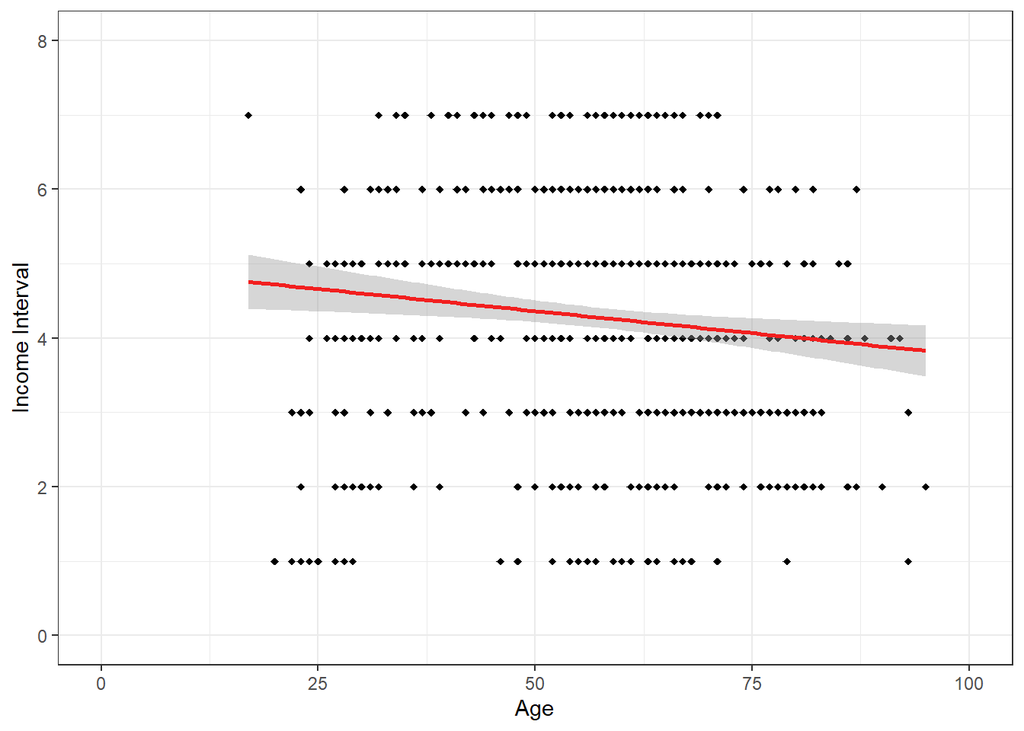

Scatter plot with trend line. Age and income of respondents.

[output not shown]

[output not shown]